# **Análisis transcriptómico espacial scRNAseq**

Este documento contiene las notas y código necesario para analizar un conjunto de datos espaciales scRNAseq de cáncer de mama: [A single-cell and spatially resolved atlas of human breast cancers](https://www.nature.com/articles/s41588-021-00911-1#Abs1). Los datos espaciales se encuentran disponibles en el repositorio [Zenodo](https://zenodo.org/records/4739739), el cual contiene las matrices de conteo, imagenes de las inminohistoímicas, un archivo de metadatos (infomración clínica y detalles patológicos) de 6 muestras de cáncer de mama primario obtenidos con la plataforma Visium assay de 10X Genomics.

Primero se debe montar y comprender el flujo de trabajo necesario para el análisis de los datos. Debemos inicar el análisis de los datos *single cell* y posteriormente integrar los datos espaciales. Para ello iniciaremos el análisis de solo una muestra: [CID44971](https://www.ncbi.nlm.nih.gov/geo/query/acc.cgi?acc=GSM5354531). Esta muestra tiene un fenotipo triple negativo (TNBC), se mapeo contra el genoma de referencia GRCh38 con el programa *CellRanger Single Cell* v2.0 (10X Genomics). El procesamineto de los datos incluyó los siguientes criterios de calidad:al menos 200 genes detectados por célula, mínimo 250 UMI (*Unique Molecular Identifer*) y menos del 20% de genes mitocondriales. Estos filtros son importantes para descartar células muertas o de baja calidad. **El análisis debe realizarse únicamente con células viables.**

**Dudas:**

- La secuenciación scRNAseq contiene entre 5000-7000 células por pozo ¿estos valores son normales?¿cuál es el parámetro ideal?
- ¿Cómo se manejan los datos crudos de secuenciación?
- ¿Los filtros empleados para eliminar ruido técnico asociado a los Drops son diferentes o redundantes a los indicados en el manual de [Seurat](https://satijalab.org/seurat/articles/pbmc3k_tutorial#standard-pre-processing-workflow)?

Una vez con los datos descargados podemos empezar a trabajar. Lo primero es establecer nuestro directorio de trabajo, en él deben encontrarse los archivos necesarios para el análisis:

- count_matrix_barcodes.tsv : Matriz con los barcodes
- count_matrix_genes.tsv : Matrz con los genes identificados
- count_matrix_sparse.mtx : Matriz de conteo (transcritos por célula)
- metadata.csv : Datos adicionales a la muestra

```r
# Establecer directorio de trabajo
setwd("D:/marval_windows/JR_MARVAL/est_INMEGEN/analyses/scrnaseq")
list.files()
```

```
[1] "count_matrix_barcodes.tsv" "count_matrix_genes.tsv"    "count_matrix_sparse.mtx"
[4] "metadata.csv"              "sc_rnaseq_test.rds"        "scrnaseq.nb.html"
[7] "scrnaseq.R"                "scrnaseq.Rmd"
```

El siguiente paso es instalar las librerías necesarias para el análisis. La librería principal es [Seurat](https://satijalab.org/seurat/articles/pbmc3k_tutorial#standard-pre-processing-workflow). Mucho de este código esta basado en su documentación.

```r
# Instalar liberias
#install.packages("Seurat")
library(Seurat)
#install.packages("dylyr")
library(dplyr)
```

Ahora cargamos los datos necesarios para el análisis, generando una matriz de genes por célula:

```r
# Cargar los archivos
# Se genera una matriz genes*celulas con los valores de expresion
counts <- ReadMtx(mtx = "count_matrix_sparse.mtx",
                  features = "count_matrix_genes.tsv",
                  cells = "count_matrix_barcodes.tsv",
                  feature.column = 1) # La matriz de los genes solo tiene 1 columna
```

El siguiente paso es crear el objeto Seurat, el cual es indispensable para el manejo de los datos:

```r
# Crear el objeto Seurat
seurat_object <- CreateSeuratObject(counts = counts,
                                    project = "scRNAseq_BreastCancer")

# Cargar el metadata
metadata <- read.csv("metadata.csv", row.names = 1)
seurat_object <- AddMetaData(seurat_object, metadata)

# Ver información del objeto
seurat_object
```

```
An object of class Seurat
29733 features across 7986 samples within 1 assay
Active assay: RNA (29733 features, 0 variable features)
 1 layer present: counts
```

**Nuestros datos constan de 29733 *features* (genes) y 7986 *samples* (células)**. Es necesario resaltar que cada transcrito representa una dimensión.

#### **Control de Calidad:**

Aquí se pretende eliminar ruido técnico de los datos, evaluando el número de genes detectados por céula, pocos genes podrína representar drops vacíos y muchos genes podrían ser resultado de la lectura de más de una célula. También se considera el número total de moléculas detectadas dentro de una célula (se correlaciona fuertemente con genes únicos). Finalmente, la presencia de genes mirocondriales es otro parametro de la validad de los datos, estos genes indican muerte y estrés celular, por ello se busca eliminarlos.

Veamos los datos antes de filtrarlos:

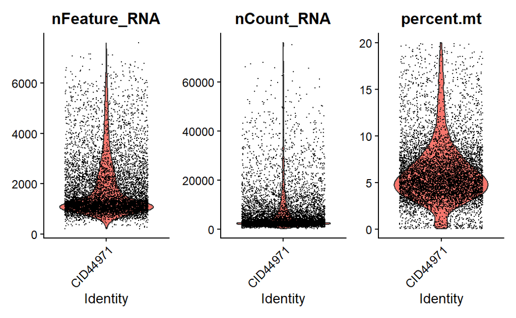

```r
# Ver métricas básicas
# Detecta genes mitocondriales
seurat_object[["percent.mt"]] <- PercentageFeatureSet(seurat_object,
                                                      pattern = "^MT-")

# Visualizar QC con Violin Plots
VlnPlot(seurat_object, features = c("nFeature_RNA", "nCount_RNA", "percent.mt"),
        ncol = 3)
```

```r
# Mostrar estadísticos de QC
summary(seurat_object$nFeature_RNA)  # Genes detectados por célula
```

```
   Min. 1st Qu.  Median    Mean 3rd Qu.    Max.
    206    1027    1303    1800    2214    7603
```

```r
summary(seurat_object$nCount_RNA)    # UMI totales por célula
```

```
   Min. 1st Qu.  Median    Mean 3rd Qu.    Max.
    254    2333    3199    6629    6909   75896
```

```r
summary(seurat_object$percent.mt)    # Porcentaje de genes mitocondriales
```

```
    Min.  1st Qu.   Median     Mean  3rd Qu.     Max.
 0.03079  3.95755  5.43269  6.10527  7.44294 19.96223
```

Los puntos de corte se seleccionaron con base en los resultados de summary pero sigue sinedo una decisión arbitraría.

```r
# Aplicar filtros:
dim(seurat_object)
```

```
[1] 29733  7986
```

```r
seurat_object <- subset(seurat_object,
                        subset = nFeature_RNA > 500 & nFeature_RNA < 4000 &
                          percent.mt < 10)

# Revisar cuántas células quedan después del filtrado
dim(seurat_object)
```

```
[1] 29733  6720
```

```r
# Mostrar estadísticos de QC
summary(seurat_object$nFeature_RNA)  # Genes detectados por célula
```

```
   Min. 1st Qu.  Median    Mean 3rd Qu.    Max.
    504    1013    1250    1525    1858    3994
```

```r
summary(seurat_object$nCount_RNA)    # UMI totales por célula
```

```
   Min. 1st Qu.  Median    Mean 3rd Qu.    Max.
    710    2288    2982    4503    5200   45261
```

```r
summary(seurat_object$percent.mt)    # Porcentaje de genes mitocondriales
```

```
   Min. 1st Qu.  Median    Mean 3rd Qu.    Max.
 0.0413  3.7863  5.0887  5.1729  6.5415  9.9971
```

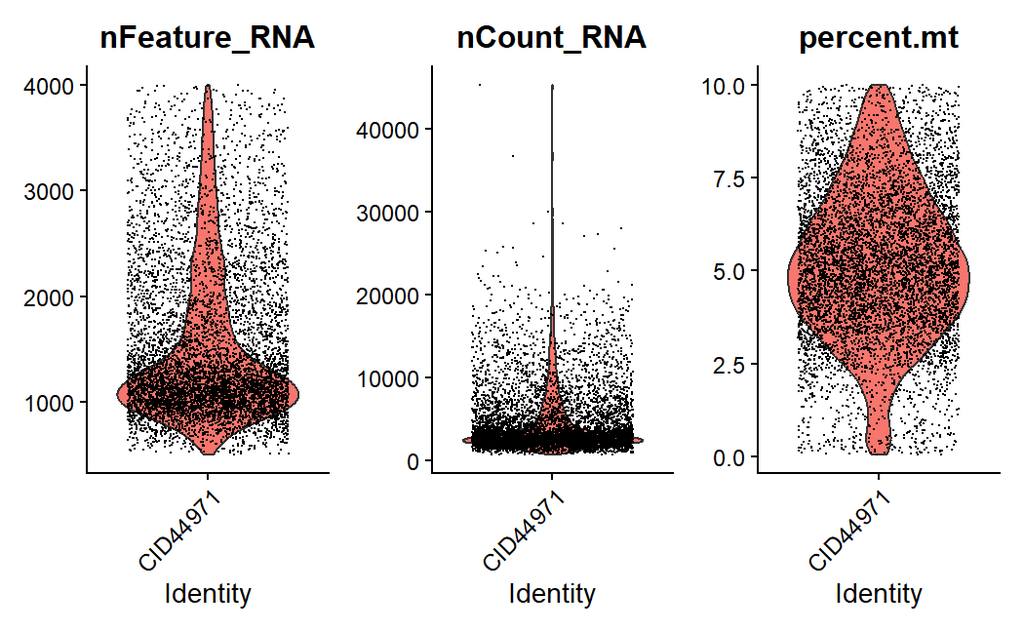

```r
# Visualizar QC con Violin Plots
VlnPlot(seurat_object, features = c("nFeature_RNA", "nCount_RNA", "percent.mt"),
        ncol = 3)
```

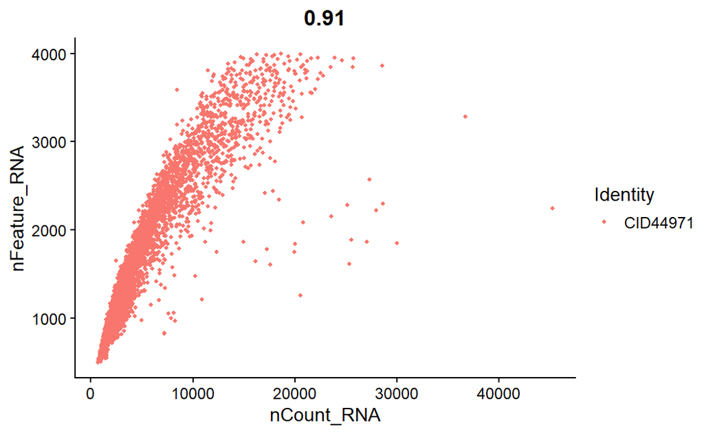

```r
# Relación entre genes detectados y UMIs por célula
FeatureScatter(seurat_object, feature1 = "nCount_RNA", feature2 = "nFeature_RNA")
```

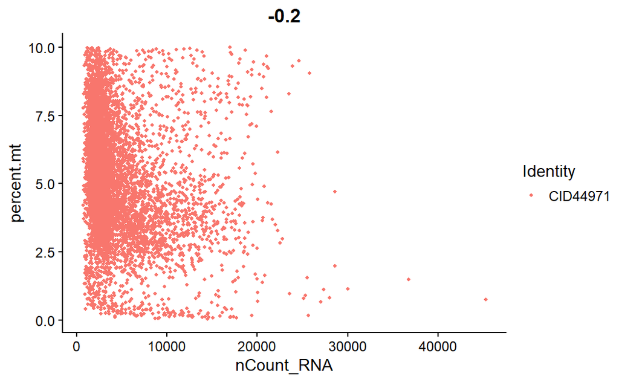

```r
# Relación entre genes detectados y porcentaje mitocondrial
FeatureScatter(seurat_object, feature1 = "nCount_RNA", feature2 = "percent.mt")
```

Con los filtros aplicados mantuve el número de transcritos pero hubo una pérdida de células. La relación entre el número de genes y el de moléculas de RNA es fuerte, lo que representa un buen indicio de la calidad de los datos.

**Dudas:**

- ¿Cómo se establecen los parámetros de calidad?¿Cómo saber los valores óptimos?

#### **Normalización:**

En este paso se pretende remover ruido técnico del análisis para tratar de garantizar que las conclusiones obtenidas son biológicamente relevantes y no se deben a rudio técnico. El método utilizado por Seurat, asume que cada célula contiene el mismo número de moléculas de RNA.

```r
seurat_object <- NormalizeData(seurat_object,
                               normalization.method = "LogNormalize",
                               scale.factor = 10000)
```

```
Normalizing layer: counts
```

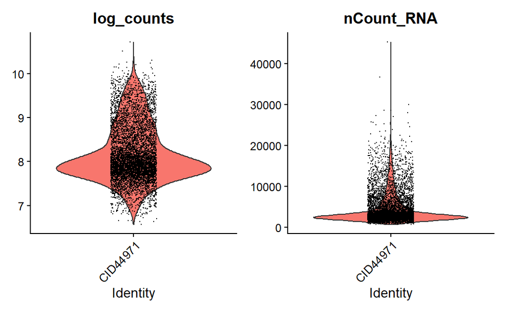

```r
# Cuentas originales vs. normalizadas
# Cuentas originales log-transformadas
seurat_object$log_counts <- log1p(seurat_object$nCount_RNA)

# Visualización con gráficos de violín
VlnPlot(seurat_object, features = c("log_counts", "nCount_RNA"),
        group.by = "orig.ident",
        pt.size = 0.1,
        split.by = "orig.ident")
```

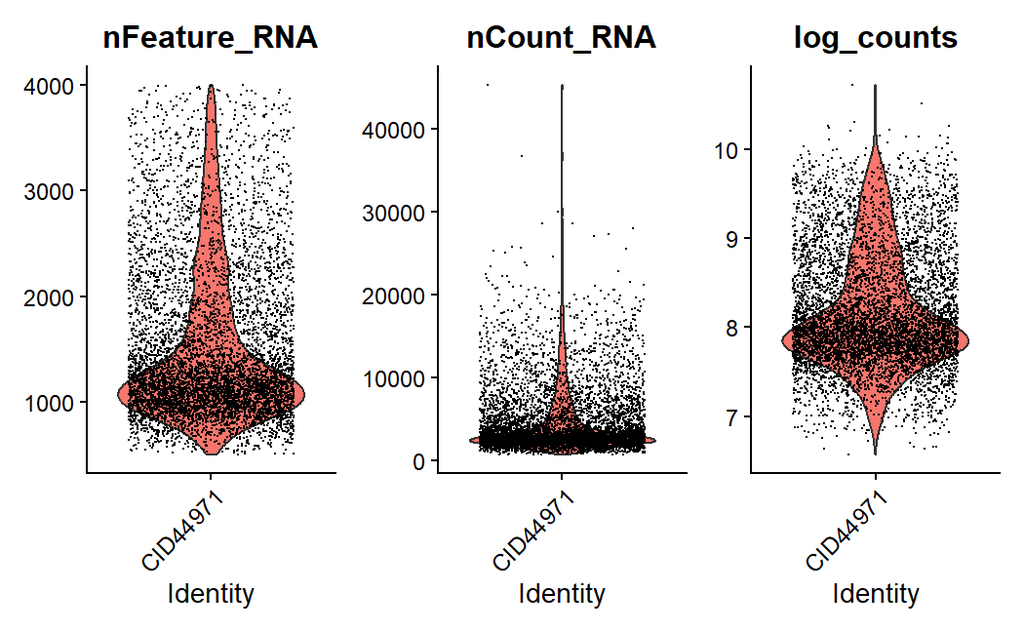

```r
# Comparar la distribución de características clave
#(genes detectados, cuentas y log-transformed counts)
VlnPlot(seurat_object, features = c("nFeature_RNA", "nCount_RNA", "log_counts"),
        ncol = 3)
```

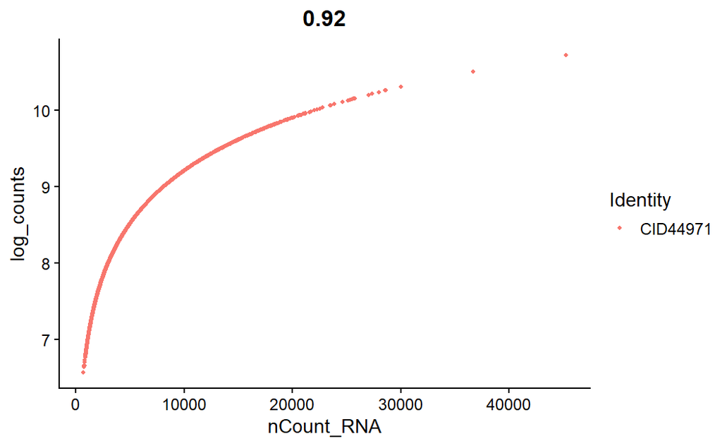

```r
FeatureScatter(seurat_object, feature1 = "nCount_RNA", feature2 = "log_counts")
```

#### **Identificación de genes con alta variabilidad:**

Este paso tiene como objetivo enfocar el análisis en los genes más variables con lo cual se pueden detectar señales biológicas interesantes. Además, ayuda a reducir la dimensionalidad de los datos y mejorar la identificación de poblaciones celulares.

```r
# Normalización usando el método de varianza estabilizada.
seurat_object <- FindVariableFeatures(seurat_object,
                                      selection.method = "vst",
                                      nfeatures = 1000)
```

```
Finding variable features for layer counts
```

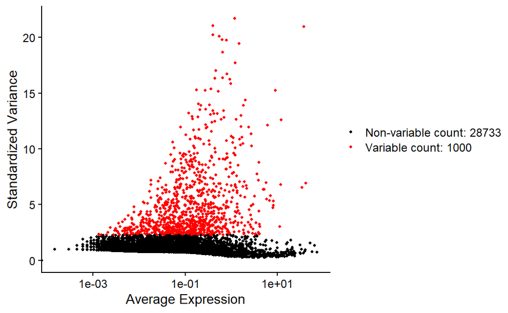

```r
# Plot de variabilidad
VariableFeaturePlot(seurat_object)
```

```
When using repel, set xnudge and ynudge to 0 for optimal results
```

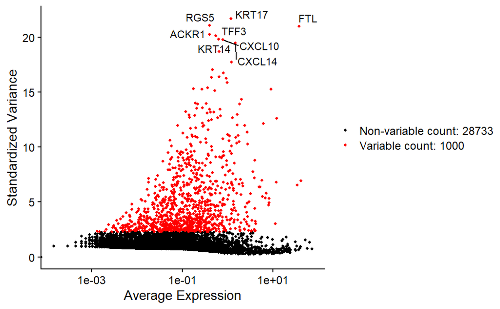

```r
# Identifiacion de genes top
top <- head(VariableFeatures(seurat_object),8)
LabelPoints(plot = VariableFeaturePlot(seurat_object), points = top,
            repel = TRUE,
            max.overlaps = 20, xnudge = 0.01, ynudge = 0.01)
```

**Dudas:**

- ¿Cómo se determina cuántos genes tomar en el parámetro *nfeatures*?

#### **Escalamiento:**

Este es un paso previo a la reducción de dimensionalidad, en cual los datos se transforman para tener una media de cero y varianza de uno. Esto genera que todos los genes tengan el mismo peso, así no hay un domino o un sesgo por genes altamente expresados. Por default se realiza sobre las características con mayor variabilidad.

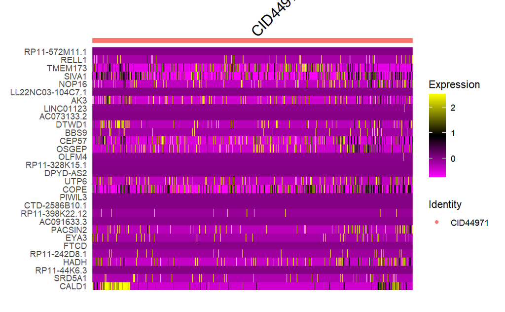

```r
# Para todos los genes del análisis
all.genes <- rownames(seurat_object)
seurat_object <- ScaleData(seurat_object, features = all.genes)
DoHeatmap(seurat_object, features = sample(all.genes, 30))
```

Usando los genes de alta variabilidad:

```r
# Para todos los genes de alta variabilidad
seurat_object <- ScaleData(seurat_object,
                           features = VariableFeatures(seurat_object))
```

```
Warning: Different features in new layer data than already exists for scale.data
```

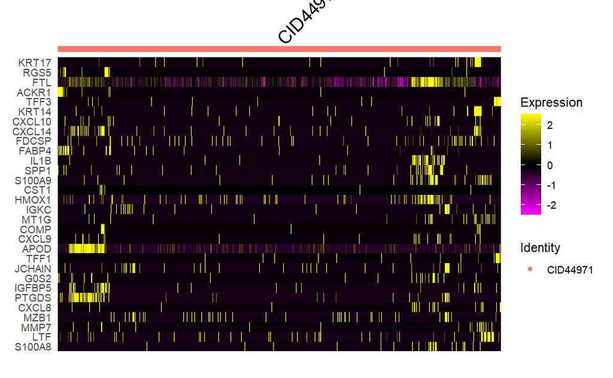

```r
DoHeatmap(seurat_object, features = head(VariableFeatures(seurat_object), 30))
```

**Dudas:**

- ¿Este paso es valido, no reduce la variación biológica de los datos pudiendo perder señales fuertes?
- ¿Qué datos se usan en el escalamiento?¿Todos los genes o solo los altamente variables?

#### **Reducción de dimensionalidad:**

Este paso se realiza sobre los datos escalados y busca representar en un espacio de menos dimensiones la complejidad dimensional de los datos.

```r
# PCA
seurat_object <- RunPCA(seurat_object,
                        features = VariableFeatures(seurat_object))
```

```
PC_ 1
Positive:  IGFBP4, SERPING1, CALD1, SPARC, CYR61, DCN, LUM, C1S, RARRES2, COL1A2
       MXRA8, COL6A2, ISLR, CXCL12, COL3A1, CTGF, CTSK, COL6A1, COL1A1, GSN
       SFRP2, CPE, PLPP3, TIMP3, EGR1, PCOLCE, MFAP4, FBLN1, NNMT, APOD
Negative:  CD74, HLA-DPA1, HLA-DRB1, HLA-DPB1, HLA-DRB5, HLA-DQA2, HLA-DQA1, CCL4, HLA-DQB1, HLA-DRA
       GZMB, TNFRSF18, PTTG1, RP11-291B21.2, GPR183, CXCL13, CCL4L2, KRT86, CD79A, MIR155HG
       CCL3, FOXP3, TRBV7-9, LTA, CRTAM, TRAV19, GCHFR, PLAC8, MS4A1, C1orf162
PC_ 2
Positive:  FCER1G, TYROBP, SPI1, AIF1, CD68, IGSF6, C1QA, C1QB, C1QC, MS4A7
       FCGR2A, MS4A6A, TREM2, FPR1, ADAP2, GRN, MNDA, FCGR3A, LYZ, LILRB4
       PILRA, HCK, MSR1, FCGR1A, CST3, CYBB, CPVL, FAM26F, CXCL16, PTAFR
Negative:  PERP, CXCL13, MGP, CD24, TNFRSF18, KRT7, CRYAB, KRT18, KRT8, MFGE8
       CLDN3, EPCAM, KRT19, RP11-291B21.2, CRABP1, PLPP2, MDK, ACTA2, CLDN4, FOXP3
       ELF5, FKBP11, KRT15, ELF3, KRT86, TRBV7-9, TPD52L1, ACTR3B, PFN2, PTTG1
PC_ 3
Positive:  TM4SF1, BCAM, KRT8, KRT18, TACSTD2, CLDN4, EFNA1, ELF3, FXYD3, CLDN7
       AZGP1, KRT7, CRIP2, CLDN3, KRT19, PERP, CRACR2B, EPCAM, PLPP2, CLU
       CD9, TINAGL1, CD24, TPD52L1, WFDC2, PALMD, PDZK1IP1, CX3CL1, S100A14, CRYAB
Negative:  LUM, DCN, COL3A1, SFRP2, COL1A2, CTSK, COL1A1, MFAP4, IGF1, COL6A3
       FBLN1, SRPX, RARRES2, COL5A2, APOD, COL6A2, MEG3, CCDC80, CXCL12, C1S
       PCOLCE, MMP2, SPON2, COL6A1, OLFML3, ISLR, NR2F1, PLTP, CD248, MXRA8
PC_ 4
Positive:  KRT8, CLDN4, KRT18, ELF3, CLDN3, TACSTD2, KRT19, EPCAM, KRT7, CD24
       AZGP1, CLDN7, FXYD3, PERP, CRYAB, MGST1, KRT15, PDZK1IP1, PLPP2, TNFRSF12A
       S100A14, SFRP1, CXCL2, WFDC2, SPDEF, SLPI, FAM3B, SDC4, PRSS8, PHLDA2
Negative:  EMCN, PLVAP, ADGRL4, VWF, ESAM, CLEC14A, SDPR, RAMP2, AQP1, EGFL7
       CXorf36, RAMP3, RBP7, GNG11, RNASE1, FLT1, SOX17, CD34, APOLD1, EPAS1
       BTNL9, ADGRF5, FABP4, CLDN5, PALMD, CD300LG, CD36, CDH5, TMEM88, PECAM1
PC_ 5
Positive:  AZGP1, MLPH, TFF3, ANKRD30A, AGR2, SPDEF, AGR3, TFF1, CLDN4, DCDC2
       ZG16B, MGP, MYBPC1, KRT19, CRACR2B, RASEF, CLDN3, ELF3, C8orf4, KIAA1324
       RND1, CLDN7, KRT18, KCNC2, STC2, CRABP2, PI15, UGT2B15, CXCL2, CD24
Negative:  MYLK, KRT14, KRT17, C2orf40, ACTG2, OXTR, TRIM29, COL17A1, TAGLN, MYH11
       SYT8, SFN, TNS4, CDH3, PPP1R14A, TPM2, ACTA2, MYL9, CNN1, DST
       KRT5, IL17B, DKK3, CALML3, FBXO32, PDLIM4, SBSPON, TPM1, TINAGL1, TGFB1I1
```

Exploremos un poco el análsis:

```r
# Exploracion de los datos
print(seurat_object[["pca"]], dims = 1:5, nfeatures = 5)
```

```
PC_ 1
Positive:  IGFBP4, SERPING1, CALD1, SPARC, CYR61
Negative:  CD74, HLA-DPA1, HLA-DRB1, HLA-DPB1, HLA-DRB5
PC_ 2
Positive:  FCER1G, TYROBP, SPI1, AIF1, CD68
Negative:  PERP, CXCL13, MGP, CD24, TNFRSF18
PC_ 3
Positive:  TM4SF1, BCAM, KRT8, KRT18, TACSTD2
Negative:  LUM, DCN, COL3A1, SFRP2, COL1A2
PC_ 4
Positive:  KRT8, CLDN4, KRT18, ELF3, CLDN3
Negative:  EMCN, PLVAP, ADGRL4, VWF, ESAM
PC_ 5
Positive:  AZGP1, MLPH, TFF3, ANKRD30A, AGR2
Negative:  MYLK, KRT14, KRT17, C2orf40, ACTG2
```

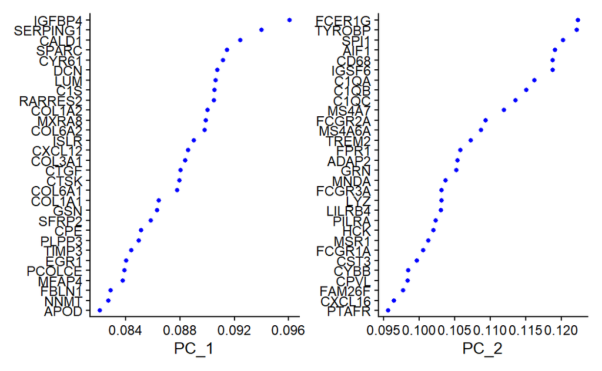

```r
# Plot de carga
VizDimLoadings(seurat_object, dims = 1:2, reduction = "pca")
```

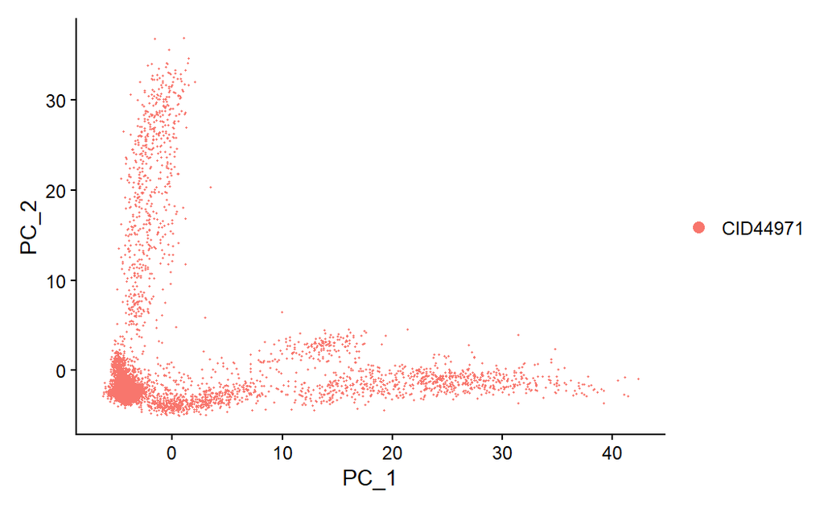

```r
# Vista del PCA
DimPlot(seurat_object, reduction = "pca")# + NoLegend()
```

Conocer el número de componentes principales que definen nuestro set de datos es importante para la definición de clusters.

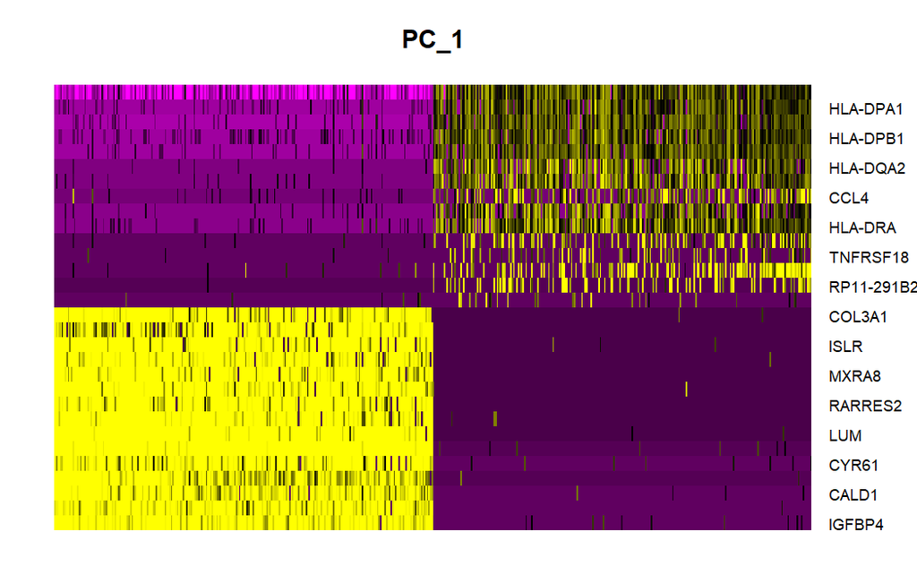

```r
# Como saber cuantos PC seleccionar?
DimHeatmap(seurat_object, dims = 1, cells = 500, balanced = TRUE)
```

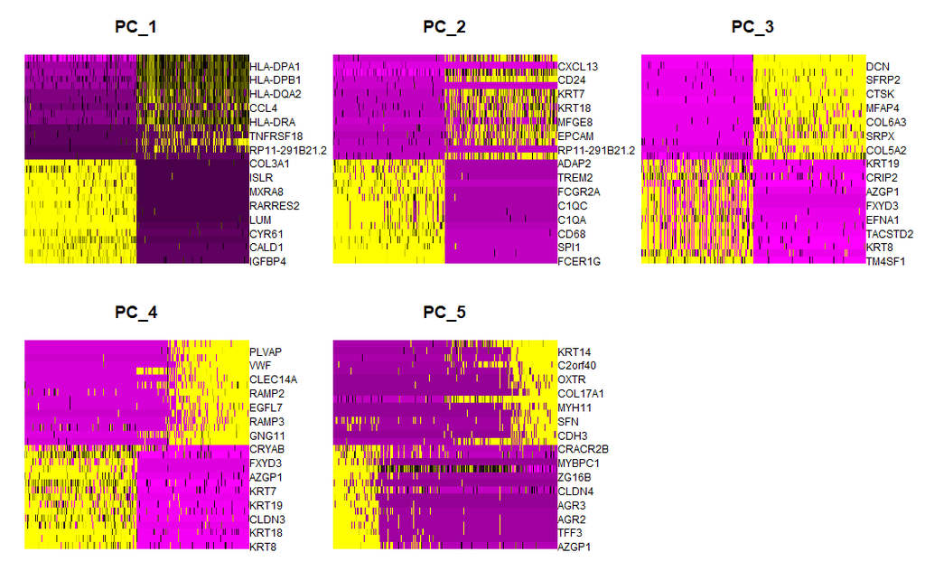

```r
DimHeatmap(seurat_object, dims = 1:5, cells = 500, balanced = TRUE)
```

**¡La elección de cuantos PC utilizar es una dicisión complicada!** El método del codo es una opción. La función de este plor en Seurat está limitada a 50 PC.

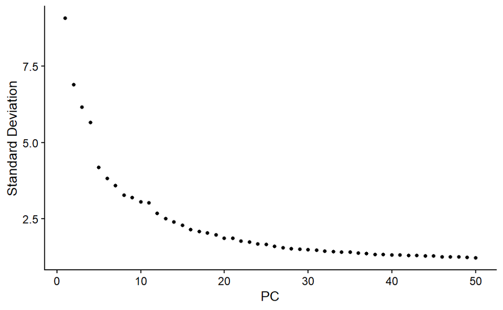

```r
# Para determinar cuántos PC usar
ElbowPlot(seurat_object, ndims = 50)
```

Prueba de JackStraw (Significancia estadística), si el PC tiene una p < 0.05 es importante para el análisis:

```r
# Cs significativos, 20 PC es el default
seurat_object <- JackStraw(seurat_object, num.replicate = 100)
```

[output not shown]

[output cut: 68 more lines]

[output not shown]

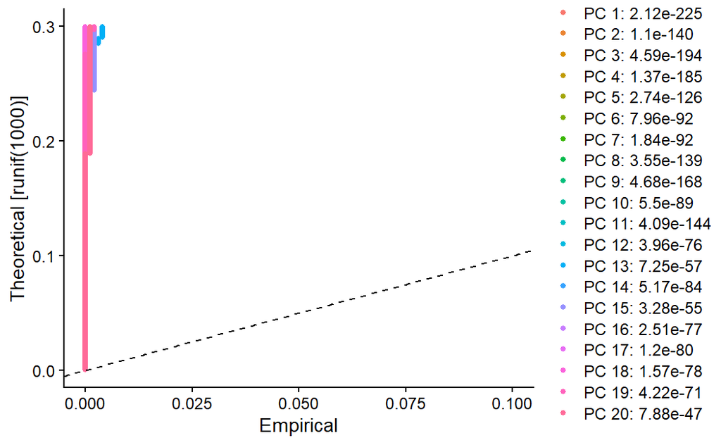

```r
seurat_object <- ScoreJackStraw(seurat_object, dims = 1:20)
JackStrawPlot(seurat_object, dims = 1:20)
```

Varianza explicada:

```r
# Umbral de varianza
# Obtener la desviación estándar de cada PC
stdev <- seurat_object[["pca"]]@stdev
# Seleccionar PCs donde la varianza explicada sea mayor a 1
num_pcs <- sum(stdev > 1)
cat("Número óptimo de PCs:", num_pcs, "\n")
```

```
Número óptimo de PCs: 50
```

Varianza acumulada:

```r
# Visualiza la proporción de varianza explicada por cada componente principal
seurat_object[["pca"]]@stdev
```

```
 [1] 9.050807 6.890155 6.151335 5.653359 4.180278 3.819395 3.592202 3.267551 3.196572
[10] 3.053093 3.017834 2.675796 2.507791 2.403516 2.292010 2.141979 2.089888 2.042105
[19] 1.977118 1.872731 1.857925 1.772749 1.740739 1.685011 1.654851 1.602189 1.557167
[28] 1.516130 1.513459 1.488677 1.471841 1.440139 1.435419 1.419520 1.408659 1.374253
[37] 1.360049 1.336624 1.329981 1.321928 1.313026 1.304340 1.299181 1.292197 1.281424
[46] 1.262121 1.259804 1.247911 1.237240 1.230338
```

```r
# Calcula la proporción de varianza explicada
var_explained <- seurat_object[["pca"]]@stdev^2 / sum(seurat_object[["pca"]]@stdev^2)
# Visualiza la varianza explicada acumulada
cumsum(var_explained)
```

```
 [1] 0.2094800 0.3308821 0.4276445 0.5093744 0.5540611 0.5913653 0.6243634 0.6516666
 [9] 0.6777964 0.7016332 0.7249227 0.7432320 0.7593144 0.7740872 0.7875211 0.7992538
[17] 0.8104228 0.8210869 0.8310831 0.8400515 0.8488788 0.8569152 0.8646640 0.8719246
[25] 0.8789276 0.8854920 0.8916927 0.8975709 0.9034283 0.9090955 0.9146353 0.9199389
[33] 0.9252079 0.9303608 0.9354351 0.9402646 0.9449948 0.9495634 0.9540868 0.9585555
[41] 0.9629642 0.9673148 0.9716311 0.9759011 0.9801001 0.9841737 0.9882322 0.9922146
[49] 0.9961291 1.0000000
```

```r
# Encuentra el número de PCs que explican el 90% de la varianza
pc_90 <- which(cumsum(var_explained) >= 0.90)[1]
pc_90
```

```
[1] 29
```

**Dudas:**

- ¿Cuál es el mejor método para seleccionar el número de PC a conservar?

#### **Clustering:**

Con base en los PC definidos se establecen los clusters inferidos en los datos. El método esta basado en grafos, de tal forma que células con patrones de expresión similares en ss genes-nodos tienden a mantenerse cercanas formando cliques y comunidades densamente conectados.

```r
# Construye las redes de vecinos, considerando  el # de PC a retener
seurat_object <- FindNeighbors(seurat_object, dims = 1:50)
# Determina el número de clusters
seurat_object <- FindClusters(seurat_object, resolution = 0.1)
```

```
Modularity Optimizer version 1.3.0 by Ludo Waltman and Nees Jan van Eck

Number of nodes: 6720
Number of edges: 308433

Running Louvain algorithm...
```

```
Maximum modularity in 10 random starts: 0.9683
Number of communities: 15
Elapsed time: 1 seconds
```

```r
# Cluster IDs of the first 5 cells
head(Idents(seurat_object), 5)
```

```
CID44971_AAGCCGCCACGCATCG CID44971_AAGGAGCTCAACACAC CID44971_ACGAGCCTCCGATATG
                        9                         9                         9
CID44971_ACGTCAATCCGAAGAG CID44971_AGAGTGGCACACGCTG
                        9                         9
Levels: 0 1 2 3 4 5 6 7 8 9 10 11 12 13 14
```

Una vez con la genración de los clusters, podemos construir la representación gráfica en un espacio de menos dimensiones.

```r
# Realizar la reducción de dimensiones con UMAP
seurat_object <- RunUMAP(seurat_object, dims = 1:50)
```

```
02:21:35 Found 3 connected components, falling back to 'spca' initialization with init_sdev = 1
02:21:35 PCA: 2 components explained 33.09% variance
02:21:35 Scaling init to sdev = 1
Using method 'umap'
```

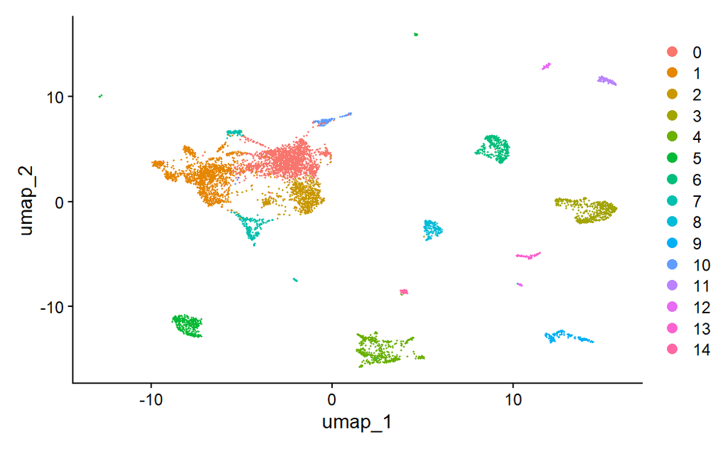

```r
# Visualizar los clusters en un gráfico UMAP
DimPlot(seurat_object, reduction = "umap")#, group.by = "seurat_clusters")
```

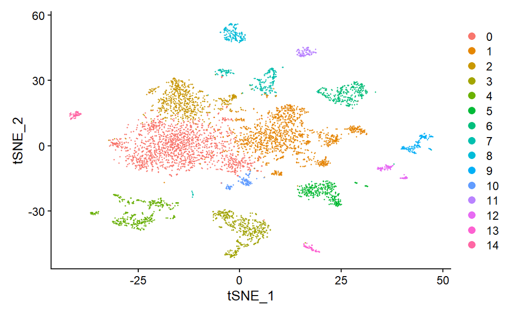

```r
# Realizar la reducción de dimensiones con t-SNE
seurat_object <- RunTSNE(seurat_object, dims = 1:50)
# Visualizar los clusters en un gráfico t-SNE
DimPlot(seurat_object, reduction = "tsne")#, group.by = "seurat_clusters")
```

Este es un buen punto para guardar el anális:

```r
# Salvar resultado
saveRDS(seurat_object, file = "sc_rnaseq_test.rds")
```

**Dudas:**

- ¿Qué es la resolución?¿Cómo determinar su valor óptimo?
- ¿Cómo discernir entre representar con UMAP o TSNE?

#### **Identificación de biomarcadores:**

Aquí con base en los genes expresados diferencialmente se encuentran los marcadores que mejor definen cada uno de los clusters.

```r
# Encontrar marcadores para cada cluster comparando contra todas las céluas
pbmc.markers <- FindAllMarkers(seurat_object, only.pos = TRUE)
```

[output not shown]

[output not shown]

[output cut: 43 more lines]

[output not shown]

[output not shown]

[output cut: 45 more lines]

[output not shown]

[output not shown]

[output cut: 46 more lines]

[output not shown]

[output not shown]

[output cut: 45 more lines]

[output not shown]

[output not shown]

[output cut: 45 more lines]

[output not shown]

[output not shown]

[output cut: 45 more lines]

[output not shown]

[output not shown]

[output cut: 46 more lines]

[output not shown]

[output not shown]

[output cut: 46 more lines]

[output not shown]

[output not shown]

[output cut: 45 more lines]

[output not shown]

[output not shown]

[output cut: 45 more lines]

[output not shown]

[output not shown]

[output cut: 46 more lines]

[output not shown]

[output not shown]

[output cut: 45 more lines]

[output not shown]

[output not shown]

[output cut: 46 more lines]

[output not shown]

[output not shown]

[output cut: 45 more lines]

[output not shown]

[output not shown]

[output cut: 46 more lines]

[output not shown]

```r
pbmc.markers %>%
  group_by(cluster) %>%
  dplyr::filter(avg_log2FC > 1)
```

| p_val | avg_log2FC | pct.1 | pct.2 | p_val_adj | cluster | gene |
| --- | --- | --- | --- | --- | --- | --- |
| 0.000000e+00 | 3.493941 | 0.878 | 0.221 | 0.000000e+00 | 0 | IL7R |
| 0.000000e+00 | 3.037335 | 0.586 | 0.117 | 0.000000e+00 | 0 | CCR7 |
| 0.000000e+00 | 1.442818 | 0.982 | 0.858 | 0.000000e+00 | 0 | SARAF |
| 0.000000e+00 | 1.182434 | 0.998 | 0.932 | 0.000000e+00 | 0 | BTG1 |
| 5.845988e-275 | 1.203040 | 0.989 | 0.926 | 1.738188e-270 | 0 | ZFP36L2 |
| 1.817120e-265 | 1.438103 | 0.939 | 0.728 | 5.402844e-261 | 0 | TSC22D3 |
| 2.984619e-260 | 3.910579 | 0.329 | 0.033 | 8.874168e-256 | 0 | CD40LG |
| 6.429291e-260 | 1.220704 | 0.935 | 0.712 | 1.911621e-255 | 0 | FXYD5 |
| 9.614039e-244 | 1.227473 | 0.795 | 0.341 | 2.858542e-239 | 0 | LTB |
| 1.584533e-231 | 1.851597 | 0.665 | 0.274 | 4.711293e-227 | 0 | GIMAP7 |

[output cut: 990 more lines]

Una vez realizado el análisis de expresión diferencial, podemos explorar la expresión de marcadores a través de cada uno de los clusters.

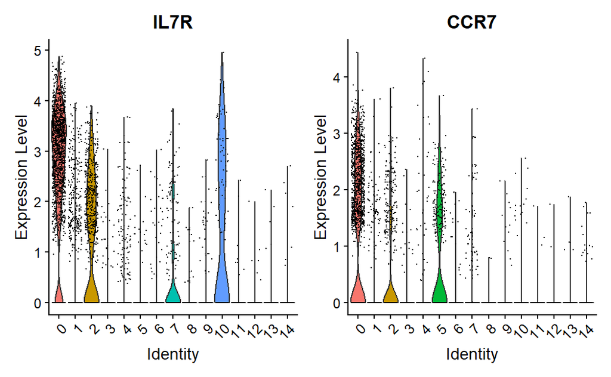

```r
# Visualizar los marcadores
VlnPlot(seurat_object, features = c("IL7R", "CCR7"))
```

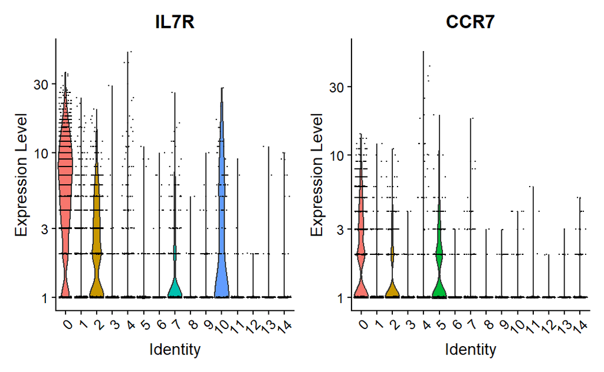

```r
# Plot raw counts
VlnPlot(seurat_object, features = c("IL7R", "CCR7"), slot = "counts", log = TRUE)
```

Pespectiva global de la distribución de un marcador en los clusters visualizado en el UMAP.

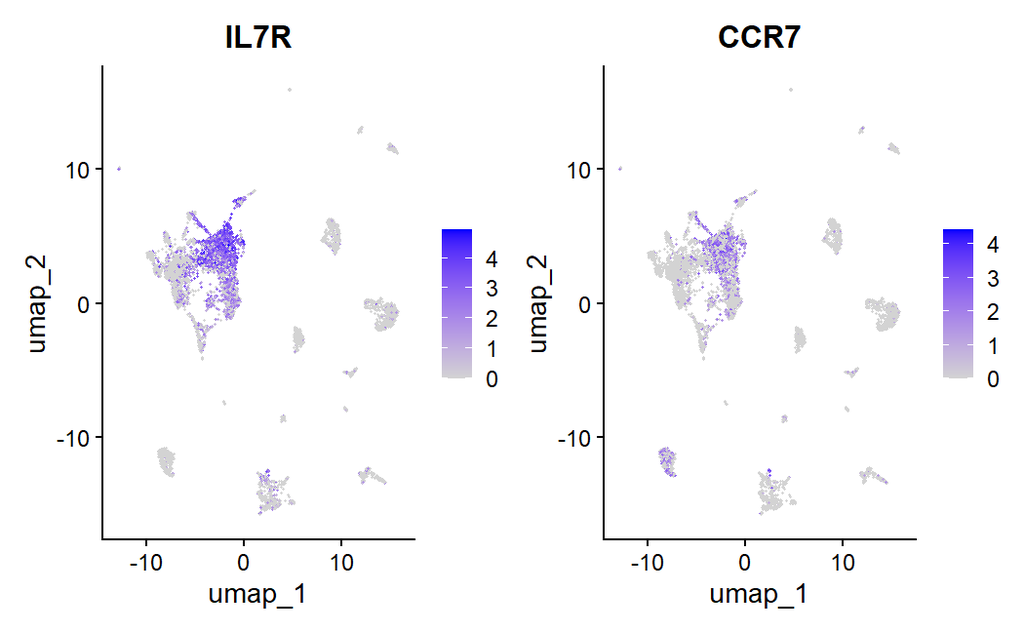

```r
# Vusaluzar en el UMAP/TSNE
FeaturePlot(seurat_object, features = c("IL7R", "CCR7"))
```

Visualización de los marcadores en un heatmap.

```r
# Heatmap
pbmc.markers %>%
  group_by(cluster) %>%
  dplyr::filter(avg_log2FC > 1) %>%
  slice_head(n = 2) %>%
  ungroup() -> top10
```

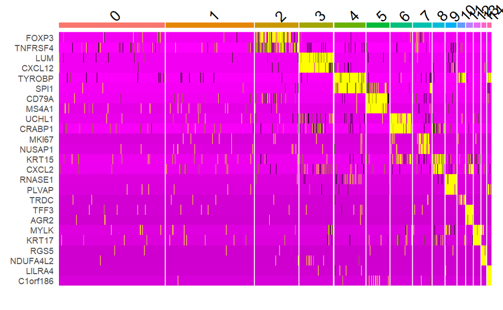

```r
DoHeatmap(seurat_object, features = top10$gene) + NoLegend()
```

**Dudas:**

- ¿Cómo se cuáles son los marcadores ideales?¿Expresión, teoría de grafos, literatura?

#### **Asiganación de tipos celulares**

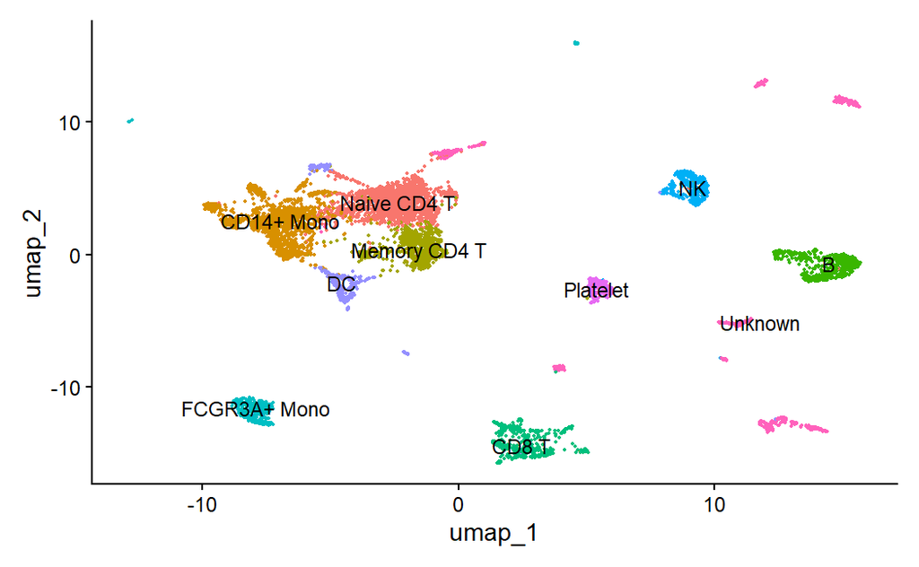

```r
new.cluster.ids <- c("Naive CD4 T", "CD14+ Mono", "Memory CD4 T", "B",
                     "CD8 T", "FCGR3A+ Mono",
                     "NK", "DC", "Platelet",
                     rep("Unknown", 6))

names(new.cluster.ids) <- levels(seurat_object)
seurat_object <- RenameIdents(seurat_object, new.cluster.ids)
DimPlot(seurat_object, reduction = "umap",
        label = TRUE, pt.size = 0.5) + NoLegend()
```

```r
library(ggplot2)
```

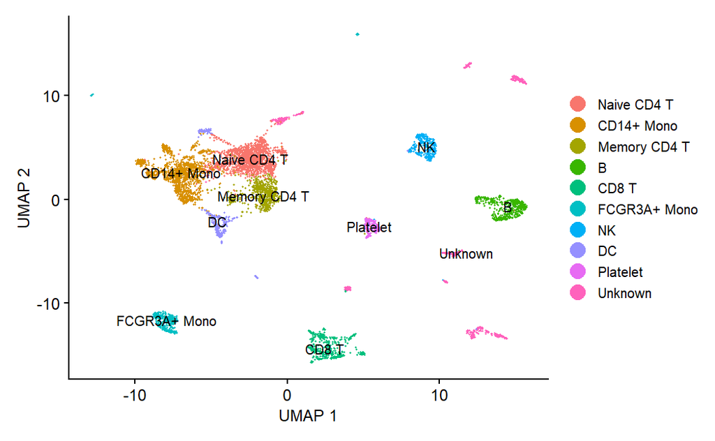

```r
plot <- DimPlot(seurat_object, reduction = "umap", label = TRUE, label.size = 3.5) +
  xlab("UMAP 1") +
  ylab("UMAP 2") +
  theme(axis.title = element_text(size = 12),
        legend.text = element_text(size = 10)) +
  guides(colour = guide_legend(override.aes = list(size = 5)))

plot
```

**Dudas:**

- ¿La asignación se puede hacer de forma autómatica?

#### **Integración con los datos espaciales:**

**¡Proximamente!**